# p8105_hw2_bs3142

Bingyu Sun

9/30/2018

```r
knitr::opts_chunk$set(echo = TRUE)

library(tidyverse) # load tidyverse library
```

```r
library(readxl)    # load readxl library

knitr::opts_chunk$set(
  fig.width = 6,
  fig.asp = .6,
  out.width = "90%"
)       # set graph format

theme_set(theme_bw() + theme(legend.position = "bottom"))
```

### Problem 1 NYC Transit Data

#### Section 1: Data Manipulation

**Data cleaning**

- Retain line, station, name, station latitude / longitude, routes served, entry, vending, entrance type, and ADA compliance
- Convert the entry variable from character to a logical variable

```r
my_nyc_transit_data =
  read_csv("./data/NYC_Transit_Subway_Entrance_And_Exit_Data.csv") %>%
  # import nyc transit data
  janitor::clean_names() %>% # clean variable names
  select(line, station_name, station_latitude, station_longitude, route1:route11, entry, vending, entrance_type, ada) %>%
  # specify variables
  mutate(entry = recode(entry, "YES" = TRUE, "NO" = FALSE))
# Convert entry variable to logical variable
```

**Summary**

1. Variables in the dataset
   - The dataset contains information about NYC transit, like station location, routes served in each station, station entrance type, vending, and ADA compliance.
2. Data cleaning steps
   - I created a data frame for cleaning raw NYC Transit data. The dataset is imported using a relative path and names are cleaned by janitor function. Specific variables in the dateset are selected. Furthermore, the entry variable has been converted to a logical vector. The resulting dataset consists of **1868** rows by **19** columns.
3. Data assessment
   - The data is untidy. There are 11 columns of route numbers that should be organized into a single column under route number with a corresponding column for route names.

#### Section 2: Data features

**1. How many distinct stations are there?**

```r
distinct_my_nyc_transit_data =
  my_nyc_transit_data %>%
  distinct(line, station_name, .keep_all = TRUE)
# make stations distinct

nrow(distinct_my_nyc_transit_data) # count number of rows
```

```
## [1] 465
```

There are **465** distinct train stations.

**2. How many stations are ADA compliant?**

```r
distinct_my_nyc_transit_data %>%
  filter(ada == "TRUE") %>% # get ADA compliant stations
  count
```

```
## # A tibble: 1 x 1
##       n
##   <int>
## 1    84
```

**84** of the 465 stations are ADA compliant.

**3. What proportion of station entrances / exits without vending allow entrance?**

```r
nrow(filter(my_nyc_transit_data, vending == "NO", entry == "TRUE")) / nrow(filter(my_nyc_transit_data, vending == "NO"))
```

```
## [1] 0.3770492
```

```r
# calc proportion
```

**37.7%** of station without vending allow entrance.

#### Section 3: Reformat data

- Transform route number and route name to distinct variables

```r
tidy_my_nyc_transit_data =
  my_nyc_transit_data %>%
  gather(key = "route_number", value = "route_name", route1:route11) %>%
  # reformat route1 to route11 into two columns
  distinct(line, station_name, .keep_all = TRUE) %>%
  filter(route_name == "A") %>% # get stations that serve train A
  filter(ada == "TRUE") # ADA compliant stations that serve train A
```

**How many distinct stations serve the A train? Of the stations that serve the A train, how many are ADA compliant?**

- There are **60** distinct stations serve Train A, and **17** of them are ADA compliant.

### Problem 2 Mr. Trash Wheel

#### Section 1: Data Manipulation of Mr. Trash Wheel sheet

**Data Cleaning**

- specify the sheet in the Excel file and to omit columns containing notes (using the range argument and cell_cols() function)
- use reasonable variable names
- omit rows that do not include dumpster-specific data
- rounds the number of sports balls to the nearest integer and converts the result to an integer variable (using as.integer)

```r
my_wheel_data =
  read_excel("./data/HealthyHarborWaterWheelTotals2018-7-28.xlsx", sheet = 1, range = cell_cols("Dumpster:Homes Powered")) %>% # import wheel data
  janitor::clean_names() %>% # clean names
  select(-x_1) %>% # remove notes
  filter(!is.na(dumpster)) %>% # remove rows without dumpster info
  mutate(sports_balls = as.integer(sports_balls)) # round values of sports balls to integers
```

#### Section 2: Data Manipulation of prcp 2016 & 2017

**Data Cleaning**

- Omit rows without precipitation data and add a variable year.
- Combine datasets and convert month to a character variable (the variable month.name is built into R and should be useful).

Prcp_2017:

```r
my_prcp_2017_data =
  readxl::read_excel("./data/HealthyHarborWaterWheelTotals2018-7-28.xlsx", sheet = 4, skip = 1) %>% # import 2017 precipitation data
  janitor::clean_names() %>% # clean names
  rename(precipitation_in = total) %>% # rename a column
  mutate(year = "2017") %>% # add a column showing year
  filter(!is.na(month), !is.na(precipitation_in)) # filter out NA
```

Prcp_2016:

```r
my_prcp_2016_data =
  readxl::read_excel("./data/HealthyHarborWaterWheelTotals2018-7-28.xlsx", sheet = 5, skip = 1) %>% # import 2016 precipitation data
  janitor::clean_names() %>% # clean names
  rename(precipitation_in = total) %>% # rename a column
  mutate(year = "2016") %>% # add a column showing year
  filter(!is.na(month), !is.na(precipitation_in)) # filter out NA
```

Prcp 2016 & 2017:

```r
my_combined_prcp_data =
  bind_rows(my_prcp_2016_data, my_prcp_2017_data) %>%
  # combine 2016 and 2017 data
  mutate(month = month.name[month])
  # change month to month name
```

**Summary**

**1. Mr. Trash Wheel**

The dataset consists of **285** rows by **14** columns. There are **285** dumpsters recorded from year 2014 to 2018. Information like date, trash amount, and types are included. The median number of sports balls in a dumpster in 2016 was **26**.

**2. Precipitation 2017**

The dataset consists of 12 observations of monthly amount of precipitation in 2017. The total precipitation in 2017 was **32.93** inches.

**3. Precipitation 2016**

The dataset consists of 12 observations of monthly amount of precipitation in 2016. The total precipitation in 2016 was **39.95** inches.

**4. Precipitation 2016 & 2017**

The dataset is a combined dataset for 2016 and 2017 precipitation data. It consists of **24** observations, one per month. One difference in the dataset is that the numeric monthes are converted to character variables.

### Problem 3

#### Section 1: Data Import

```r
library(p8105.datasets)
data(brfss_smart2010) # import BRFSS data
```

#### Section 2: Data Manipulation

- Format the data to use appropriate variable names
- Focus on the “Overall Health” topic
- Exclude variables for class, topic, question, sample size, and everything from lower confidence limit to GeoLocation
- Structure data so that values for Response (“Excellent” to “Poor”) are column names / variables which indicate the proportion of subjects with each response (which are values of Data_value in the original dataset)
- Create a new variable showing the proportion of responses that were “Excellent” or “Very Good”

```r
my_brfss_data =
  brfss_smart2010 %>%
  janitor::clean_names() %>%
  filter(topic == "Overall Health") %>%
  # select rows based on overall health
  select(-(class:question), -sample_size, -(confidence_limit_low:geo_location)) %>%
  spread(key = response, value = data_value) %>%
  # reformat response
  janitor::clean_names() %>%
  mutate(prop_excellent_and_very_good = (excellent + very_good))
# add a column of proportion for excellent and very good
```

**Summary**

**1. How many unique locations are included in the dataset? Is every state represented? What state is observed the most?**

The dataset contains **404** unique locations, in **51** states. Therefore, every state is represented. **NJ** (New Jersey) state is observed the most.

**2. In 2002, what is the median of the “Excellent” response value?**

In 2002, the median of the “Excellent” response value is **23.6**.

#### Section 3: Plots

1. **Histogram** of “Excellent” response values in the year 2002

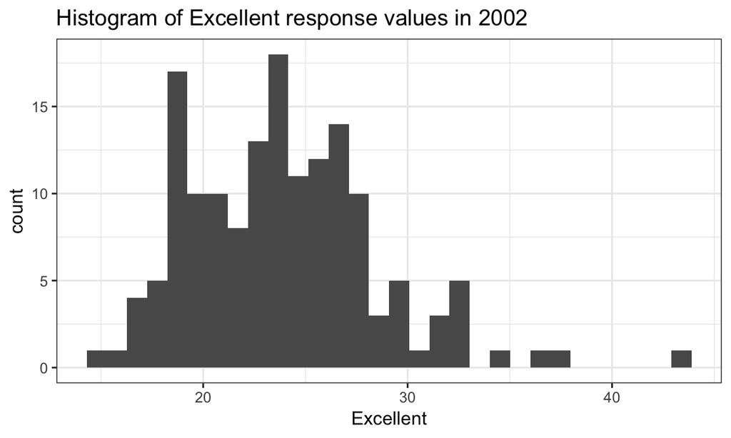

```r
my_brfss_data %>%
  select(year, excellent) %>%
  filter(year == "2002") %>%
  # retain only 2002 data
  ggplot(aes(x = excellent)) +
  geom_histogram() +
  labs(x = "Excellent",
       title = "Histogram of Excellent response values in 2002")
```

```r
# plot histogram
```

2. **Scatterplot** showing the proportion of “Excellent” response values in New York County and Queens County (both in NY State) in each year from 2002 to 2010

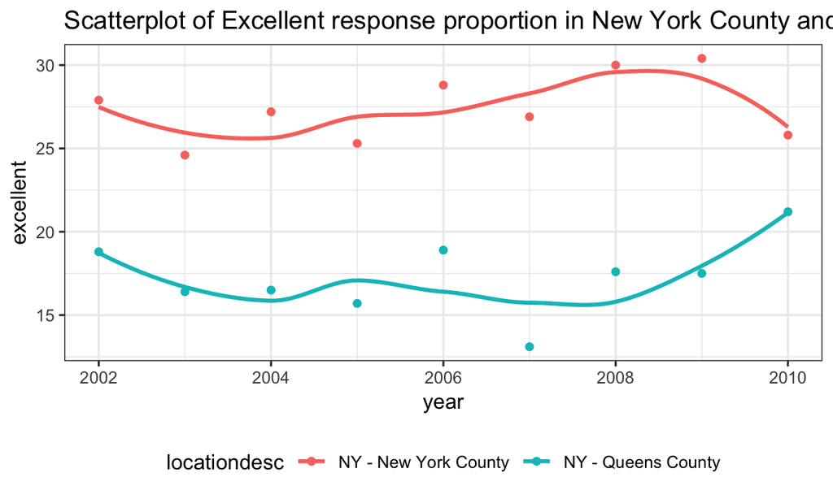

```r
my_brfss_data %>%
  select(year, locationdesc, excellent) %>%
  filter(locationdesc %in% c("NY - New York County", "NY - Queens County")) %>%
  # retain New York County and Queens County info
  ggplot(aes(x = year, y = excellent, color = locationdesc)) +
  geom_point() +
  geom_smooth(se = FALSE) +
  labs(title = "Scatterplot of Excellent response proportion in New York County and Queens Country in 2002 to 2010")
```

```r
# plot scatterplot
```